# Titanic

## Количествените непрекъснати данни

### Fare

```r
head(titanic$Fare)
```

```
[1]  7.25 71.28  7.92 53.10  8.05  8.46
```

Вариационият ред

```r
head(sort(titanic$Fare),100)
```

```
  [1] 0.00 0.00 0.00 0.00 0.00 0.00 0.00 0.00 0.00 0.00 0.00 0.00 0.00 0.00 0.00 4.01 5.00 6.24 6.44 6.45 6.50
 [22] 6.50 6.75 6.75 6.86 6.95 6.97 6.97 7.05 7.05 7.05 7.05 7.05 7.05 7.05 7.05 7.05 7.05 7.12 7.12 7.12 7.12
 [43] 7.14 7.22 7.22 7.22 7.22 7.22 7.22 7.22 7.22 7.22 7.22 7.22 7.22 7.23 7.23 7.23 7.23 7.23 7.23 7.23 7.23
 [64] 7.23 7.23 7.23 7.23 7.23 7.23 7.23 7.25 7.25 7.25 7.25 7.25 7.25 7.25 7.25 7.25 7.25 7.25 7.25 7.25 7.31
 [85] 7.50 7.50 7.50 7.52 7.55 7.55 7.55 7.55 7.63 7.65 7.65 7.65 7.65 7.72 7.73 7.73
```

```r
tail(sort(titanic$Fare),100)
```

```
  [1]  73.5  73.5  73.5  75.2  76.3  76.7  76.7  76.7  77.3  77.3  78.0  78.0  78.0  78.3  78.3  78.8  78.8
 [18]  79.2  79.2  79.2  79.2  79.7  79.7  79.7  80.0  80.0  81.9  82.2  82.2  83.2  83.2  83.2  83.5  83.5
 [35]  86.5  86.5  86.5  89.1  89.1  90.0  90.0  90.0  90.0  91.1  91.1  93.5  93.5 106.4 106.4 108.9 108.9
 [52] 110.9 110.9 110.9 110.9 113.3 113.3 113.3 120.0 120.0 120.0 120.0 133.7 133.7 134.5 134.5 135.6 135.6
 [69] 135.6 146.5 146.5 151.6 151.6 151.6 151.6 153.5 153.5 153.5 164.9 164.9 211.3 211.3 211.3 211.5 221.8
 [86] 227.5 227.5 227.5 227.5 247.5 247.5 262.4 262.4 263.0 263.0 263.0 263.0 512.3 512.3 512.3
```

Минимална стойност за цена на билет

```r
min(titanic$Fare)
```

```
[1] 0
```

Максимална стойност за цена на билет

```r
max(titanic$Fare)
```

```
[1] 512
```

Средната цена на билетите

```r
mean(titanic$Fare)
```

```
[1] 32.2
```

Медиана на цените на билетите

```r
median(titanic$Fare)
```

```
[1] 14.5
```

Дисперсия на цените на билетите

```r
var(titanic$Fare)
```

```
[1] 2469
```

Стандартно отклонение на цените на билетите

```r
sd(titanic$Fare)
```

```
[1] 49.7
```

Първи квартил

```r
quantile((titanic$Fare), 0.25)
```

```
 25%
7.91
```

Трети квартил

```r
quantile((titanic$Fare), 0.75)
```

```
75%
 31
```

Размах (Range) R = max - min..

```r
range(titanic$Fare)[2] - range(titanic$Fare)[1]
```

```
[1] 512
```

```r
diff(range(titanic$Fare))
```

```
[1] 512
```

Интерквартилен размах (IQR)

```r
IQR(titanic$Fare)
```

```
[1] 23.1
```

.. Min H_lower Median H_upper Max

```r
fivenum(titanic$Fare)
```

```
[1]   0.00   7.91  14.45  31.00 512.33
```

.. Min 1st_Q Median Mean 3rd_Q Max NA

```r
summary(titanic$Fare)
```

```
   Min. 1st Qu.  Median    Mean 3rd Qu.    Max.
      0       8      14      32      31     512
```

Хистограма

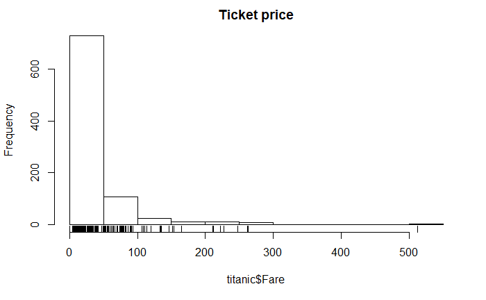

```r
hist(titanic$Fare,
     include.lowest = TRUE,
     right = TRUE,
     main = "Ticket price")
rug(jitter(titanic$Fare))
```

Кутия с мустачки

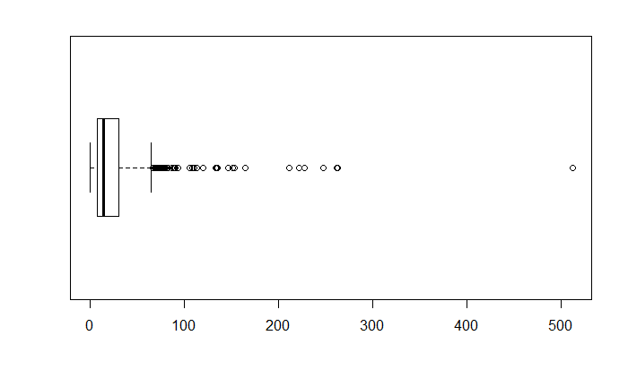

```r
boxplot(titanic$Fare,
        horizontal = TRUE)
```

Хистограма и курия с мустачки

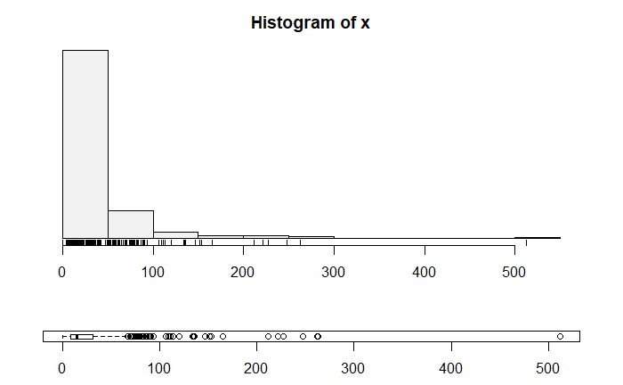

```r
simple.hist.and.boxplot(titanic$Fare)
```

Полигон

```r
h = hist(titanic$Fare)
h$breaks
```

```
 [1]   0  50 100 150 200 250 300 350 400 450 500 550
```

```r
h$counts
```

```
 [1] 731 107  24   9  11   6   0   0   0   0   3
```

```r
h$density
```

```
 [1] 1.64e-02 2.40e-03 5.39e-04 2.02e-04 2.47e-04 1.35e-04 0.00e+00 0.00e+00 0.00e+00 0.00e+00 6.73e-05
```

```r
h$mids
```

```
 [1]  25  75 125 175 225 275 325 375 425 475 525
```

```r
h$xname
```

```
[1] "titanic$Fare"
```

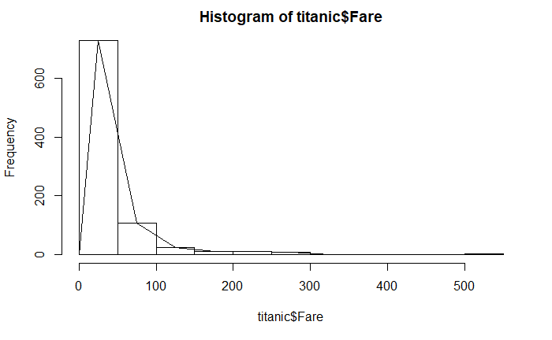

```r
lines(c(min(h$breaks), h$mids, max(h$breaks)),
      c(0, h$counts, 0),
      type = "l")
```

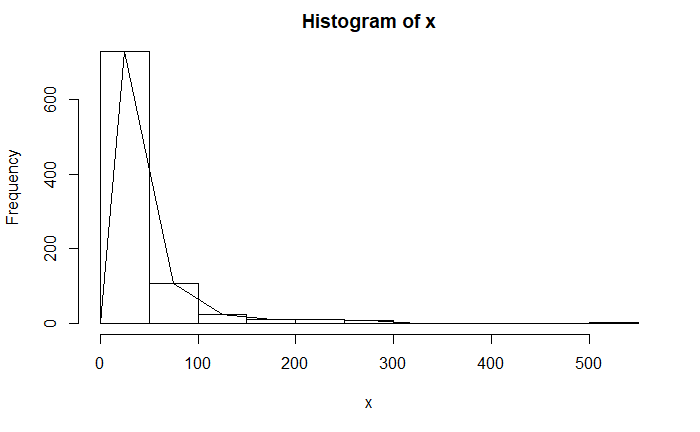

```r
simple.freqpoly(titanic$Fare)
```

Плътност (Density)

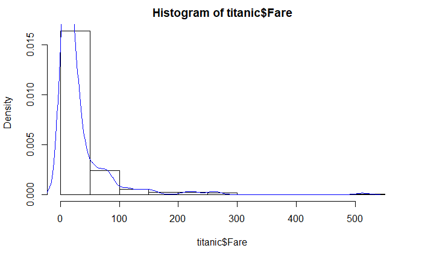

```r
hist(titanic$Fare,
     probability = TRUE)
lines(density(titanic$Fare, bw = 10), col = "blue")
```

Може да се опитате да анализирате резултатите, да си поиграете повече с графиките, като използвате latice и ggplot и да приложите знанията от следващите лекции за 2 и повече променливи.